# Warranty Claim Classification Using Machine Learning with [Scikit-Learn](http://scikit-learn.org)

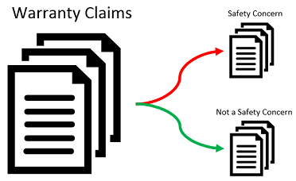

```python
from IPython.display import Image
Image(filename='FnS.png')
```

### Goal:

To automatically flag warranty claims as possible customer safety concern using machine learning classification with Python's scikit-learn library

### Current situation:

`Some_Company_Division` currently uses a large and complex query (implemented with IF/ELSE type of logic via SQL's CASE statement) to flag claims as customer safety issue. The study is to determine if we can apply machine learning classification to do the flagging instead. This study could potentially lead to other areas of warranty or market data that could benefit from machine learning classification.

### The Data:

The data consists of 2 feature or attribute columns and a target or label column that would be used as input to train a machine learning algorithm.

**Features columns:**

- warranty claim part # (text, categorical data type)
- customer complaint description (free-hand text, document data type)

**Target / label column:**

- A binary/2-value flag to indicate whether or not the claim is a potential safety concern

NOTE: This sample data used for training was purposely made to be small to help facilitate faster work flow. Inevitably, special methods will be needed if this process were to be applied in production with very large training data - see references at the very bottom of this notebook.

### Before going into Python code, here is a high level process overview of the machine learning classification process

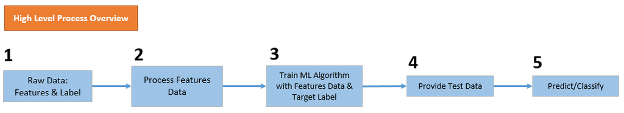

```python
Image(filename='High_Level_Process.png')
```

### The following is Python code that I am using to implement the classification based on this [example](http://scikit-learn.org/stable/tutorial/text_analytics/working_with_text_data.html) from scikit-learn's web site.

```python
import pandas as pd
from IPython.display import Image
from scipy import sparse
from sklearn.preprocessing import LabelEncoder,OneHotEncoder
from sklearn.feature_extraction.text import CountVectorizer
from sklearn.feature_extraction.text import TfidfTransformer
from sklearn.naive_bayes import MultinomialNB
```

# Step 1: Working with raw data - features and label

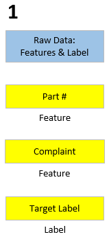

```python
Image(filename='Step1.png')
```

```python
data_set = pd.read_csv('FnS_temp.csv', usecols=[4,7,8])
```

### Sample Data:

```python
data_set.head()
```

|  | SHRT_PART_NO | ORIG_CUST_CNTN_TXT | TARGET |
| --- | --- | --- | --- |
| 0 | 01473 | DURING LAST SERVICE INSPECTION TECH FOUND LEFT... | 0 |
| 1 | 04712 | CLIENT STATES THERE IS DAMAGE UNDER FRONT BUMP... | 0 |
| 2 | 04712 | CLIENT STATES THERE IS DAMAGE UNDER FRONT BUMP... | 1 |
| 3 | 04715 | CUSTOMER STATES REAR RIGHT BUMPER IS OUT OF AL... | 1 |
| 4 | 04715 | PER DPSM SUBLET LR QUARTER TO BODY SHOP | 1 |

### Create the 2 features variables and the one target variable

```python
partno = data_set.SHRT_PART_NO.values
complaints = data_set.ORIG_CUST_CNTN_TXT.values
target = data_set.TARGET.values
```

# Step 2: Process the part # and Complaint features data

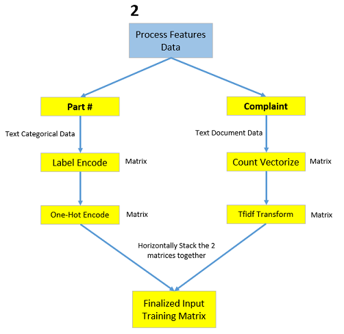

```python
Image(filename='Step2.png')
```

## Process the part # feature data

### `partno` is a categorical variable consisting of string value, so need to perform Label Encoding on it

```python
enc_label = LabelEncoder()
X_train_partno_labelencoded = enc_label.fit_transform(partno)
```

```python
X_train_partno_labelencoded
```

```
array([  0,   1,   1,   2,   2,   3,   4,   5,   5,   5,   6,   7,   8,
         9,  10,  11,  12,  13,  14,  14,  15,  15,  15,  15,  15,  15,
        15,  15,  15,  15,  15,  15,  15,  15,  15,  15,  15,  15,  16,
        17,  18,  18,  18,  18,  18,  19,  20,  20,  21,  22,  22,  22,
        22,  22,  22,  22,  22,  22,  22,  22,  22,  22,  22,  22,  22,
        22,  22,  23,  24,  25,  25,  26,  27,  28,  28,  28,  28,  29,
        30,  31,  32,  33,  34,  35,  36,  36,  36,  36,  36,  36,  36,
        37,  38,  38,  39,  39,  40,  41,  41,  41,  41,  41,  42,  42,
        42,  42,  42,  43,  44,  45,  45,  46,  46,  46,  47,  47,  48,
        48,  48,  48,  48,  49,  50,  51,  52,  53,  54,  54,  54,  54,
        54,  54,  55,  56,  57,  57,  57,  58,  59,  60,  61,  61,  62,
        62,  62,  63,  64,  65,  66,  66,  67,  68,  69,  70,  71,  71,
        71,  71,  71,  72,  73,  74,  75,  76,  77,  78,  79,  79,  80,
        80,  81,  81,  82,  82,  83,  84,  85,  85,  85,  86,  86,  86,
        86,  86,  87,  87,  87,  87,  88,  88,  88,  88,  88,  88,  89,
        89,  89,  89,  89,  89,  90,  90,  90,  90,  90,  91,  91,  91,
        92,  92,  92,  92,  92,  92,  92,  92,  92,  93,  93,  93,  94,
        95,  96,  97,  98,  99, 100, 101, 102, 103, 103, 103, 104, 105,
       106, 107, 107, 108, 109, 110, 111, 112, 113, 113, 114, 115, 115,
       116, 117, 118, 119, 120, 121, 122, 123, 124, 124, 125, 126, 127,
       128, 128, 129, 129, 130, 131, 132, 133, 134, 135, 135, 136, 136,
       137, 138, 139, 140, 141, 141, 142, 142, 142, 143, 143, 144, 145,
       146, 147, 148, 148, 148, 148, 148, 149, 149, 150, 151, 151, 151,
       151, 152], dtype=int32)
```

```python
X_train_partno_labelencoded.shape
```

```
(301,)
```

### Now we can perform one-hot encoding on the label encoded data:

```python
enc_onehot = OneHotEncoder()
X_train_partno_onehot = enc_onehot.fit_transform(X_train_partno_labelencoded)
```

```
d:\Miniconda3\envs\notebook\lib\site-packages\sklearn\utils\validation.py:395: DeprecationWarning: Passing 1d arrays as data is deprecated in 0.17 and will raise ValueError in 0.19. Reshape your data either using X.reshape(-1, 1) if your data has a single feature or X.reshape(1, -1) if it contains a…
  DeprecationWarning)
```

### Due to deprecation warning, converting 1-D part # training data to 2-D with `reshape(-1,1)`:

```python
X_train_partno_onehot = enc_onehot.fit_transform(X_train_partno_labelencoded.reshape(-1,1))
```

```python
temp = enc_onehot.fit(X_train_partno_labelencoded.reshape(-1,1))
```

```python
X_train_partno_onehot
```

```
<301x153 sparse matrix of type '<class 'numpy.float64'>'
	with 301 stored elements in Compressed Sparse Row format>
```

```python
X_train_partno_onehot.shape
```

```
(301, 153)
```

```python
X_train_partno_onehot.data
```

[output not shown]

## Process the customer complaint feature data

**`complaints`** is a feature column containing string values, but it is not categorical since it is not limited to a known number of values. So in this case, to my understanding, I would tranform with CountVectorizer and then TfidfTransformer per this scikit-learn [example](http://scikit-learn.org/stable/tutorial/text_analytics/working_with_text_data.html) on working with text data

### `Vectorize` the complaints training data with `CountVectorizer`

```python
count_vect = CountVectorizer()
X_train_complaint_counts = count_vect.fit_transform(complaints)
X_train_complaint_counts.shape
```

```
(301, 1141)
```

### `Transform` the complaints training data with `tfidf`

```python
tfidf_transformer = TfidfTransformer()
X_train_complaint_tfidf = tfidf_transformer.fit_transform(X_train_complaint_counts)
X_train_complaint_tfidf.shape
```

```
(301, 1141)
```

```python
type(X_train_complaint_tfidf)
```

```
scipy.sparse.csr.csr_matrix
```

### Combine/concatenate the partno feature with the complaint feature data along the column axis or horizontal axis

Horizontally stack the 2 matrices together:

```python
X_train_combined_tfidf = sparse.hstack((X_train_partno_onehot, X_train_complaint_tfidf), format='csr')
```

```python
X_train_combined_tfidf
```

```
<301x1294 sparse matrix of type '<class 'numpy.float64'>'
	with 4451 stored elements in Compressed Sparse Row format>
```

# Step 3: Train the machine learning algorithm

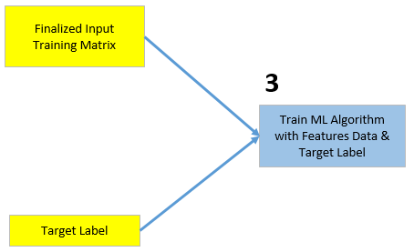

```python
Image(filename='Step3.png')
```

### Train to a model (Multinomial Naive Bayes)

```python
clf = MultinomialNB().fit(X_train_combined_tfidf, target)
```

# Steps 4 and 5: Provide test data and predict label

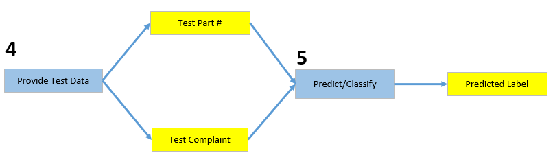

```python
Image(filename='Steps4-5.png')
```

```python
part_test = np.array(['19301'])
complaint_test = np.array(['CLIENT STATES THE CHECK EMISSIONS LIGHT IS ON'])

X_new_part_labelencoded = enc_label.fit_transform(part_test)
X_new_part_onehot = enc_onehot.fit_transform(X_new_part_labelencoded.reshape(-1,1))

X_new_complaint_counts = count_vect.transform(complaint_test)
X_new_complaint_tfidf = tfidf_transformer.transform(X_new_complaint_counts)

# Horizontally stack together the 2 sparse matrices
X_new_combined_tfidf = sparse.hstack((X_new_part_onehot, X_new_complaint_tfidf), format='csr')

predicted = clf.predict(X_new_combined_tfidf)
```

[output not shown]

**I got a `dimension mismatch` error, but why?**

### Let's output the dimensions of my input data

```python
X_new_part_onehot.shape
```

```
(1, 1)
```

```python
X_new_complaint_tfidf.shape
```

```
(1, 1141)
```

```python
X_new_combined_tfidf.shape
```

```
(1, 1142)
```

### Corrected code:

```python
part_test = np.array(['19301'])
complaint_test = np.array(['CLIENT STATES THE CHECK EMISSIONS LIGHT IS ON'])

X_new_part_labelencoded = enc_label.fit_transform(part_test)

# Need to instantiate a new OneHoteEncoder object and set the n_values parameter
# or elses we'll end up with a 1x1 matrix when we need to end up with a 1x153 matrix
enc_onehot_new = OneHotEncoder(n_values=153)
X_new_part_onehot = enc_onehot_new.fit_transform(X_new_part_labelencoded.reshape(-1,1))

X_new_complaint_counts = count_vect.transform(complaint_test)
X_new_complaint_tfidf = tfidf_transformer.transform(X_new_complaint_counts)

# Horizontally stack together the 2 sparse matrices
X_new_combined_tfidf = sparse.hstack((X_new_part_onehot, X_new_complaint_tfidf), format='csr')

predicted = clf.predict(X_new_combined_tfidf)
```

Now the prediction works and it flags the **19301 / CLIENT STATES THE CHECK EMISSIONS LIGHT IS ON** combination to 0/zero:

```python
predicted
```

```
array([0], dtype=int64)
```

### References:

- Practical Business Python [article](http://pbpython.com/categorical-encoding.html) on encoding categorical data
- Since the article above does not mention Tf-idf transformation, here's a wikipedia [article](https://en.wikipedia.org/wiki/Tf–idf) on it.
- scikit-learn's [example](http://scikit-learn.org/stable/tutorial/text_analytics/working_with_text_data.html) on how to work with text data.
- When processing the feature data, they end up in a data format called `sparse matrix`. Refer to this wikipedia [article](https://en.wikipedia.org/wiki/Sparse_matrix) for more information.
- scikit-learn [suggestion](http://scikit-learn.org/stable/modules/scaling_strategies.html) on how to handle very large data; also reason why I chose Multinomial Naive Bayes algorithm since I will eventually have to use very large training data. MultinomialNB supports partial_fit() method which supports processing data in "chunks" or pieces at a time.